# CMPINF 2130 Summer 2022 - Week 03

### 3 variables

#### Categorical

We can use the marker shape, marker color, marker size, marker transparency as visual attributes to display the 3rd variable.

However, it’s usually best practice to use color and/or shape for categorical variables.

Let’s start by mapping the `Species` to the marker `color` aesthetic.

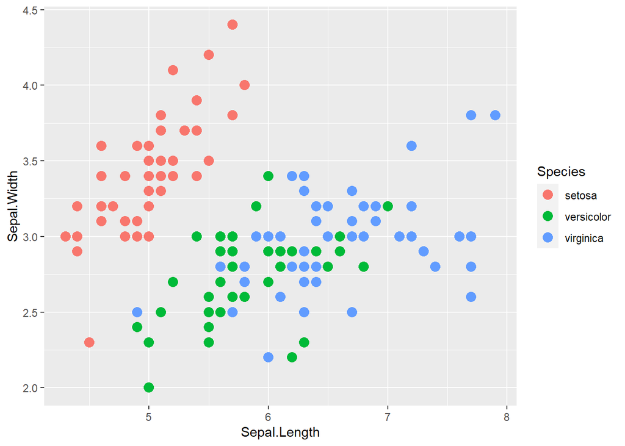

```r
iris %>%
  ggplot(mapping = aes(x = Sepal.Length, y = Sepal.Width)) +
  geom_point(mapping = aes(color = Species),
             size = 3.5)
```

We could map all aesthetics in the parent ggplot() call, but I don’t like to do this.

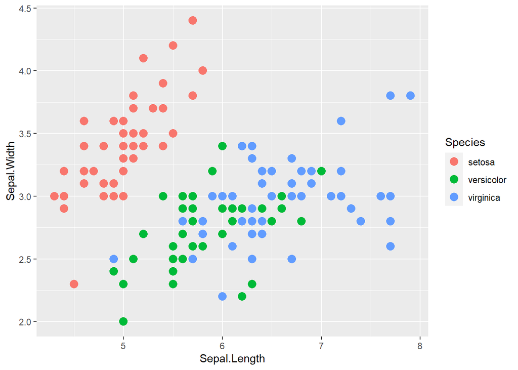

```r
iris %>%
  ggplot(mapping = aes(x = Sepal.Length, y = Sepal.Width,
                       color = Species)) +
  geom_point(size = 3.5)
```

We can try using shape instead of color for categorical variables.

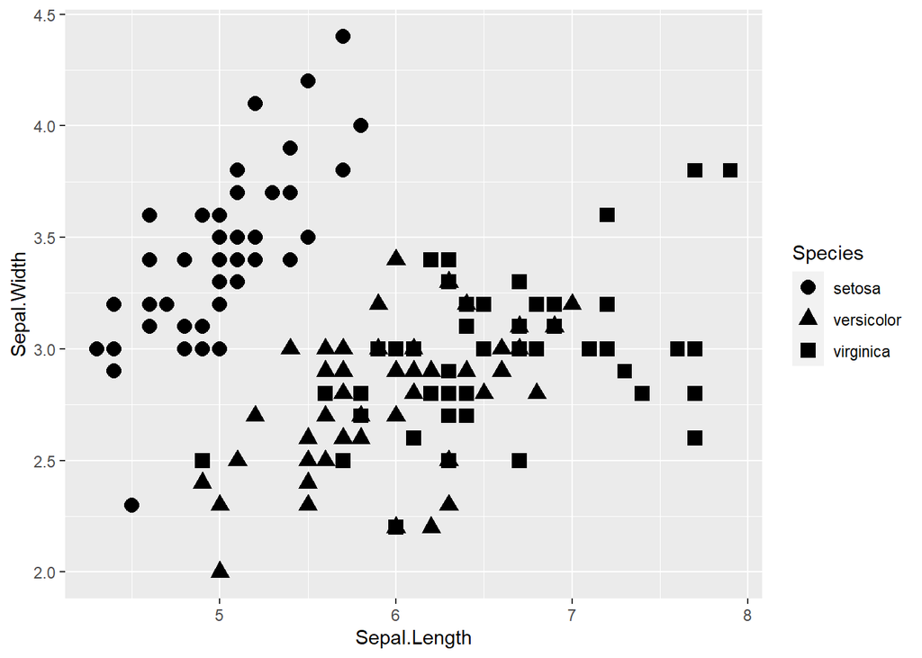

```r
iris %>%
  ggplot(mapping = aes(x = Sepal.Length, y = Sepal.Width)) +
  geom_point(size = 3.5,
             mapping = aes(shape = Species))
```

Sometimes non-solid markers can also help with identifying overlap.

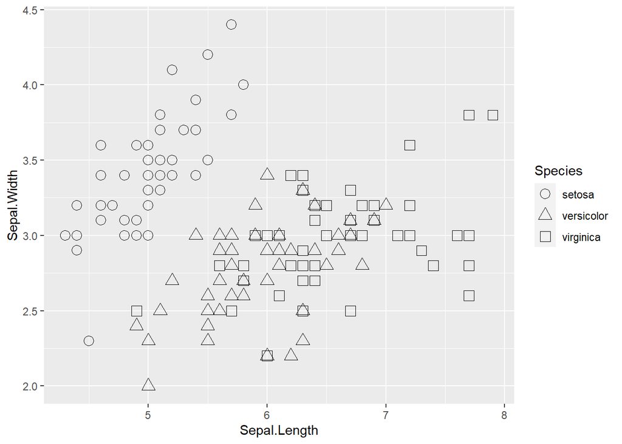

```r
iris %>%
  ggplot(mapping = aes(x = Sepal.Length, y = Sepal.Width)) +
  geom_point(size = 3.5,
             mapping = aes(shape = Species)) +
  scale_shape_discrete(solid = FALSE)
```

When we are only working with 3 variables we can use shape and color for a categorical.

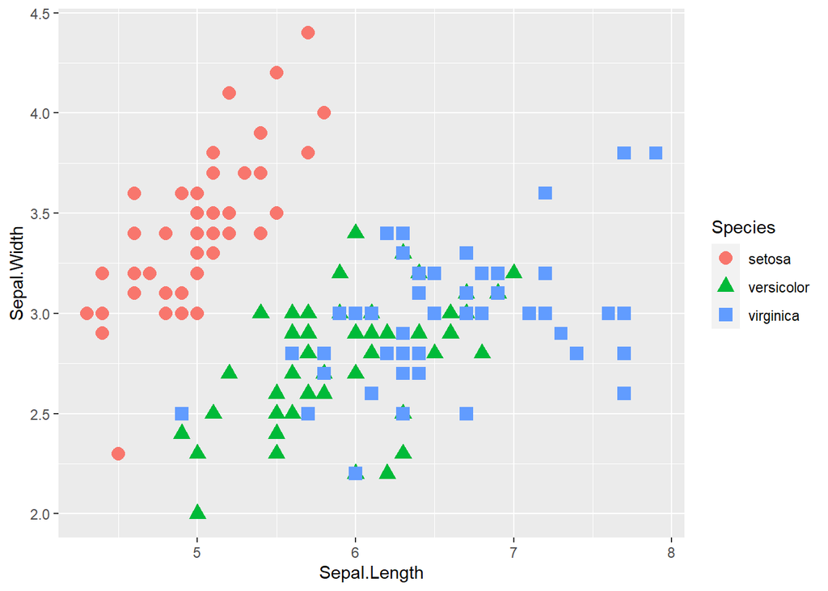

```r
iris %>%
  ggplot(mapping = aes(x = Sepal.Length, y = Sepal.Width)) +
  geom_point(size = 3.5,
             mapping = aes(shape = Species,
                           color = Species))
```

Lastly, let’s hard code the transparency to help with overlap.

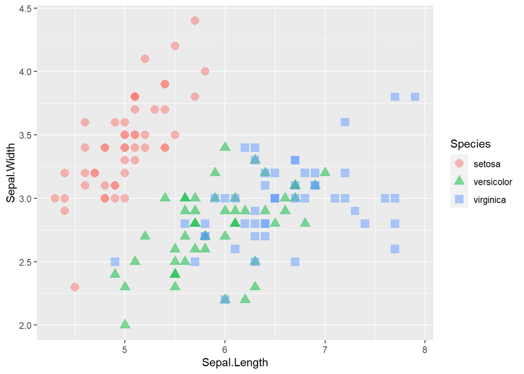

```r
iris %>%
  ggplot(mapping = aes(x = Sepal.Length, y = Sepal.Width)) +
  geom_point(size = 3.5,
             mapping = aes(shape = Species,
                           color = Species),
             alpha = 0.5)
```

We can manually define the shapes.

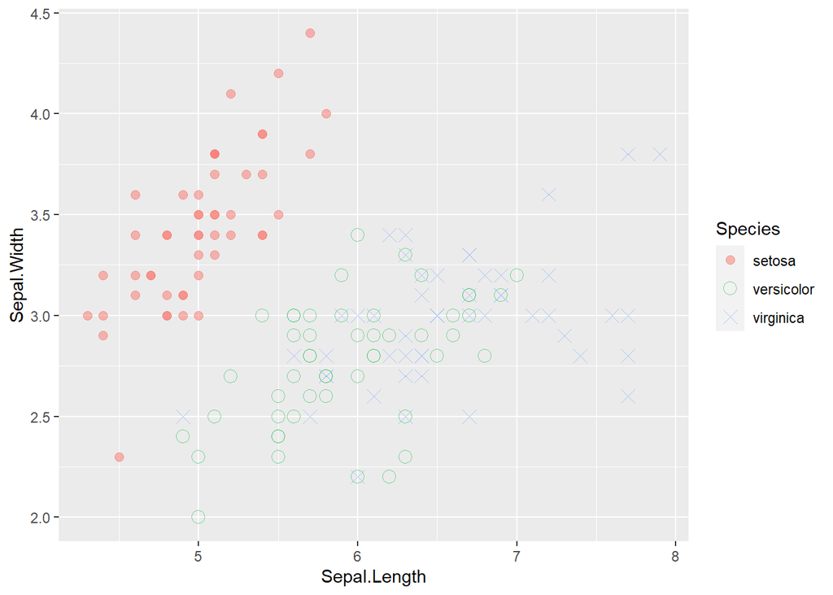

```r
iris %>%
  ggplot(mapping = aes(x = Sepal.Length, y = Sepal.Width)) +
  geom_point(size = 3.5,
             mapping = aes(shape = Species,
                           color = Species),
             alpha = 0.5) +
  scale_shape_manual(values = c('setosa' = 20,
                                'versicolor' = 21,
                                'virginica' = 4))
```

Sometimes we just want to look a manually identified BINARIZED version of a categorical variable.

We can define a new variable with `mutate()` to correspond to the binarized “event”.

```r
iris %>%
  mutate(species_binary = ifelse(Species == 'setosa',
                                 'setosa species',
                                 'something else')) %>%
  select(Species, species_binary) %>%
  count(Species, species_binary)
```

```
##      Species species_binary  n
## 1     setosa setosa species 50
## 2 versicolor something else 50
## 3  virginica something else 50
```

We can use our manually created variable to color.

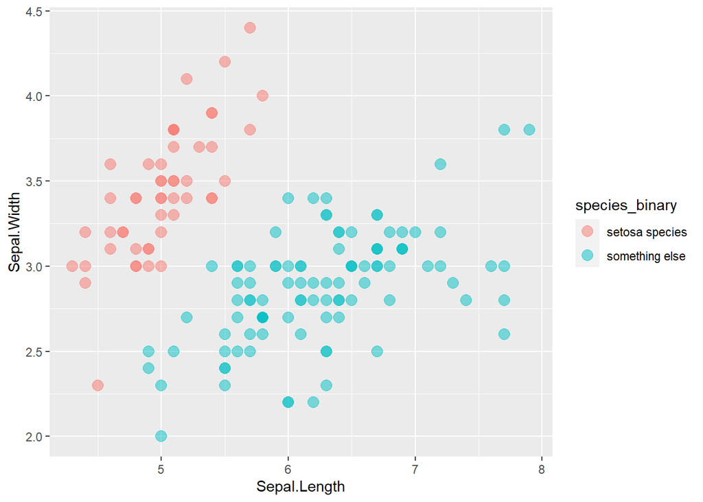

```r
iris %>%
  mutate(species_binary = ifelse(Species == 'setosa',
                                 'setosa species',
                                 'something else')) %>%
  ggplot(mapping = aes(x = Sepal.Length, y = Sepal.Width)) +
  geom_point(mapping = aes(color = species_binary),
             size = 3.5, alpha = 0.5)
```

We can manually create variables in `ggplot2` functions.

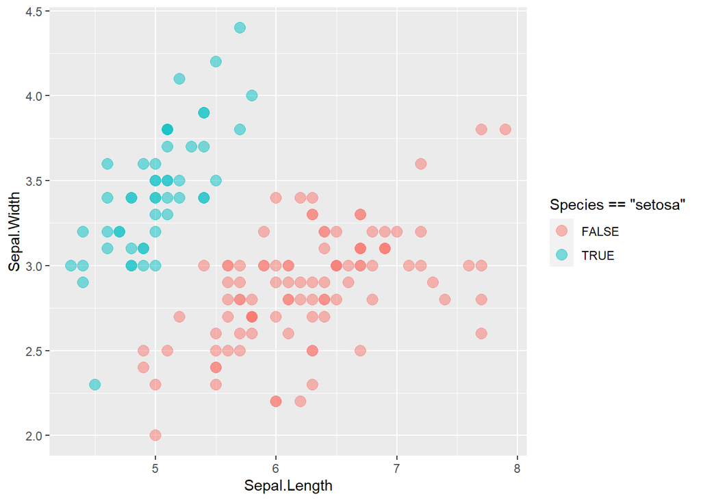

```r
iris %>%
  ggplot(mapping = aes(x = Sepal.Length, y = Sepal.Width)) +
  geom_point(mapping = aes(color = Species == 'setosa'),
             size = 3.5, alpha = 0.5)
```

If the legend is ever too long…we can move it to the top or bottom of the figure.

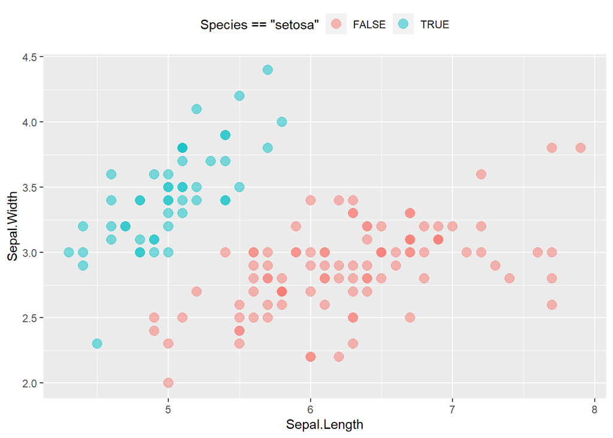

```r
iris %>%
  ggplot(mapping = aes(x = Sepal.Length, y = Sepal.Width)) +
  geom_point(mapping = aes(color = Species == 'setosa'),
             size = 3.5, alpha = 0.5) +
  theme(legend.position = 'top')
```

We can apply the direct conditional test to multiple aesthetics.

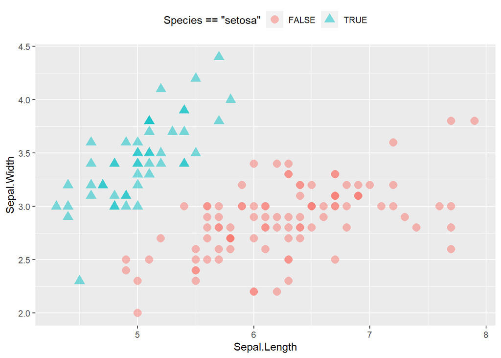

```r
iris %>%
  ggplot(mapping = aes(x = Sepal.Length, y = Sepal.Width)) +
  geom_point(mapping = aes(color = Species == 'setosa',
                           shape = Species == 'setosa'),
             size = 3.5, alpha = 0.5) +
  theme(legend.position = 'top')
```

To demonstrate working with a larger number of categories let’s randomly assign letters to the rows of `iris`.

```r
LETTERS
```

```
##  [1] "A" "B" "C" "D" "E" "F" "G" "H" "I" "J" "K" "L" "M" "N" "O" "P" "Q" "R" "S"
## [20] "T" "U" "V" "W" "X" "Y" "Z"
```

Randomly sample or shuffle the letters via the `sample()` function.

```r
set.seed(2130)
sample(LETTERS)
```

```
##  [1] "Z" "P" "W" "V" "G" "O" "T" "E" "J" "Q" "I" "L" "K" "B" "M" "U" "A" "X" "R"
## [20] "N" "H" "F" "S" "C" "Y" "D"
```

We need to sample **WITH REPLACEMENT**.

```r
set.seed(2130)
sample(LETTERS, size = nrow(iris), replace = TRUE)
```

```
##   [1] "Z" "P" "W" "V" "G" "O" "W" "V" "W" "T" "E" "J" "V" "S" "S" "Q" "Y" "O"
##  [19] "K" "O" "R" "R" "R" "A" "G" "Q" "Z" "A" "X" "Q" "E" "D" "K" "N" "G" "I"
##  [37] "E" "N" "I" "G" "N" "F" "S" "R" "F" "A" "Y" "H" "X" "M" "T" "N" "O" "H"
##  [55] "A" "L" "R" "B" "K" "A" "K" "T" "M" "P" "Y" "Q" "D" "A" "S" "B" "D" "Q"
##  [73] "Q" "O" "Y" "W" "L" "J" "Z" "M" "J" "L" "I" "Y" "O" "R" "A" "F" "R" "R"
##  [91] "P" "D" "Y" "O" "A" "W" "X" "P" "Q" "Z" "U" "Q" "E" "O" "G" "H" "W" "I"
## [109] "R" "L" "D" "L" "B" "L" "P" "W" "V" "G" "Q" "Q" "O" "H" "L" "N" "N" "K"
## [127] "J" "G" "A" "Q" "P" "Z" "L" "J" "V" "T" "U" "E" "H" "Z" "K" "V" "W" "A"
## [145] "J" "Z" "B" "A" "X" "E"
```

Let’s add the randomly shuffled letters to `iris`.

```r
set.seed(2130)
iris %>%
  mutate(random_letters = sample(LETTERS, size = n(), replace = TRUE)) %>%
  count(random_letters)
```

```
##    random_letters  n
## 1               A 11
## 2               B  4
## 3               D  5
## 4               E  6
## 5               F  3
## 6               G  7
## 7               H  5
## 8               I  4
## 9               J  6
## 10              K  6
## 11              L  8
## 12              M  3
## 13              N  6
## 14              O  9
## 15              P  6
## 16              Q 11
## 17              R  9
## 18              S  4
## 19              T  4
## 20              U  2
## 21              V  6
## 22              W  8
## 23              X  4
## 24              Y  6
## 25              Z  7
```

First, check adding a column based on a condition.

```r
iris %>%
  mutate(a_new_variable = 'A',
         b_new_variable = Species == 'setosa',
         c_new_variable = ifelse(Species == 'setosa',
                                 'the setosa species',
                                 'a different species'),
         d_new_variable = ifelse(Species == 'setosa',
                                 101,
                                 -101)) %>%
  head()
```

```
##   Sepal.Length Sepal.Width Petal.Length Petal.Width Species a_new_variable
## 1          5.1         3.5          1.4         0.2  setosa              A
## 2          4.9         3.0          1.4         0.2  setosa              A
## 3          4.7         3.2          1.3         0.2  setosa              A
## 4          4.6         3.1          1.5         0.2  setosa              A
## 5          5.0         3.6          1.4         0.2  setosa              A
## 6          5.4         3.9          1.7         0.4  setosa              A
##   b_new_variable     c_new_variable d_new_variable
## 1           TRUE the setosa species            101
## 2           TRUE the setosa species            101
## 3           TRUE the setosa species            101
## 4           TRUE the setosa species            101
## 5           TRUE the setosa species            101
## 6           TRUE the setosa species            101
```

Now that we know how to add the random shuffled letter colum let’s color by this new variable.

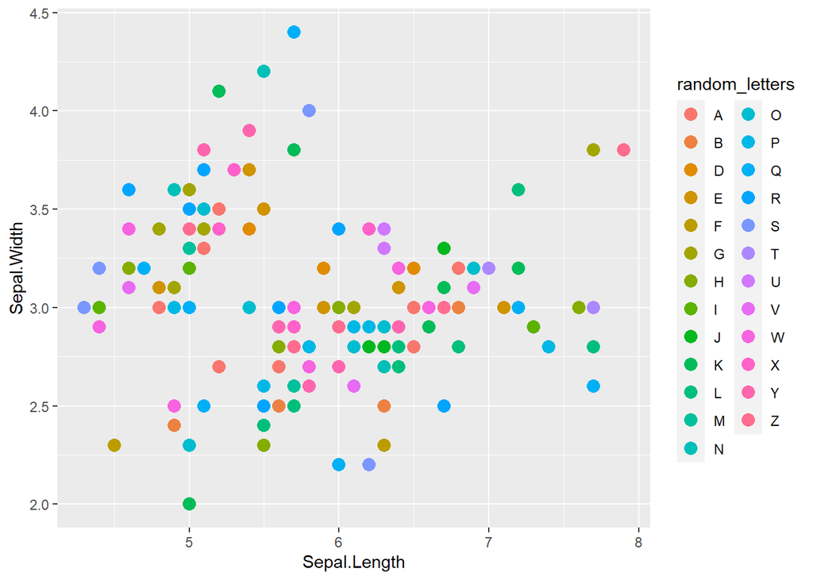

```r
set.seed(2130)
iris %>%
  mutate(random_letters = sample(LETTERS, size = n(), replace = TRUE)) %>%
  ggplot(mapping = aes(x = Sepal.Length, y = Sepal.Width)) +
  geom_point(mapping = aes(color = random_letters),
             size = 3.5)
```

What if we use shape as an aesthetic for our randomly shuffled letters?

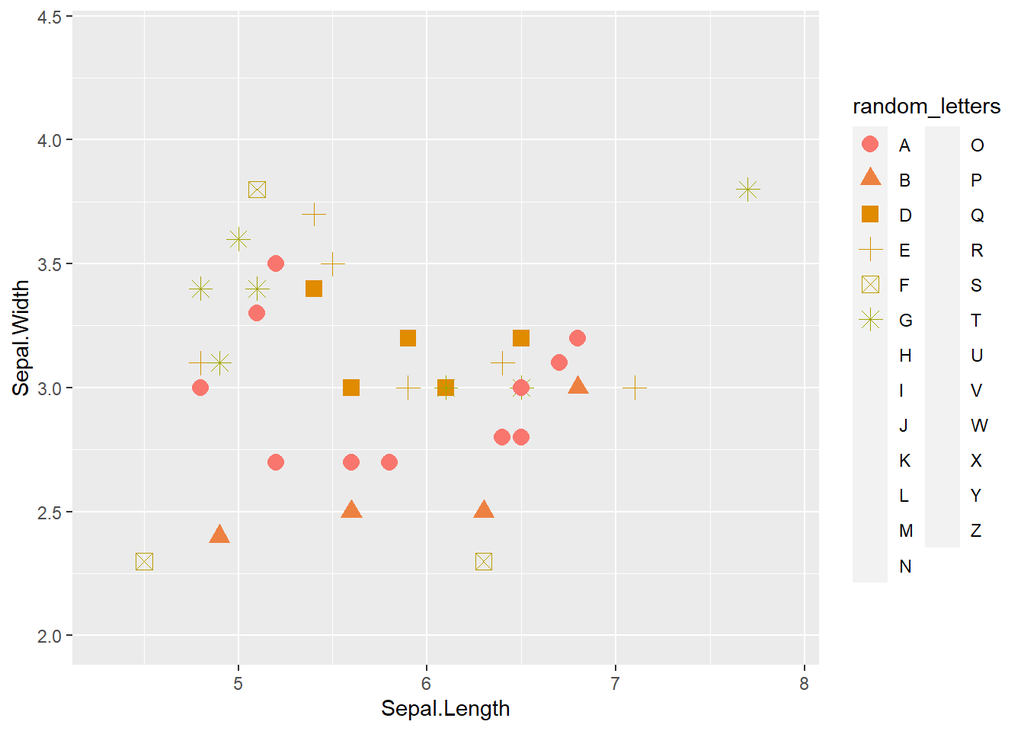

```r
set.seed(2130)
iris %>%
  mutate(random_letters = sample(LETTERS, size = n(), replace = TRUE)) %>%
  ggplot(mapping = aes(x = Sepal.Length, y = Sepal.Width)) +
  geom_point(mapping = aes(color = random_letters,
                           shape = random_letters),
             size = 3.5)
```

Other categorical color scales.

Modify the luminance or lightness of the markers.

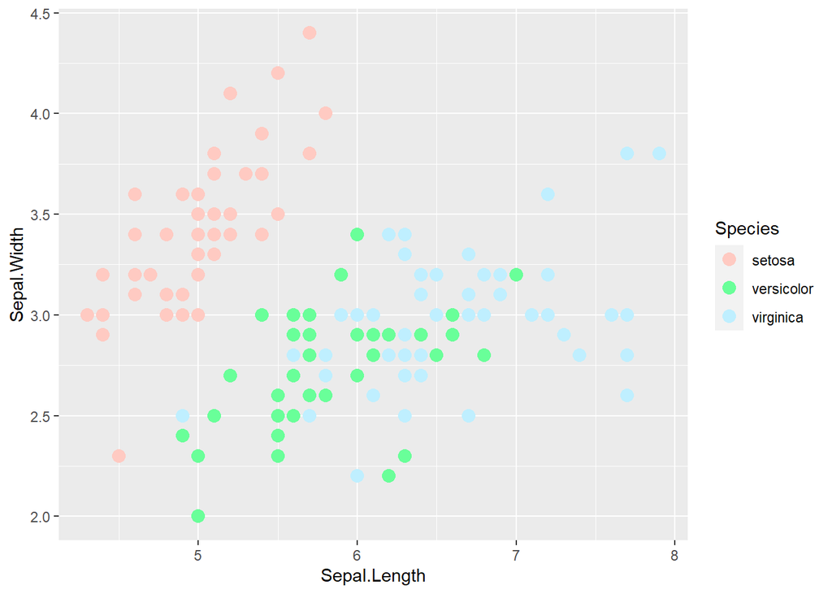

```r
iris %>%
  ggplot(mapping = aes(x = Sepal.Length, y = Sepal.Width)) +
  geom_point(size = 3.5,
             mapping = aes(color = Species)) +
  scale_color_discrete(l = 95)
```

Modifying the colors may require us to change the background panel colors.

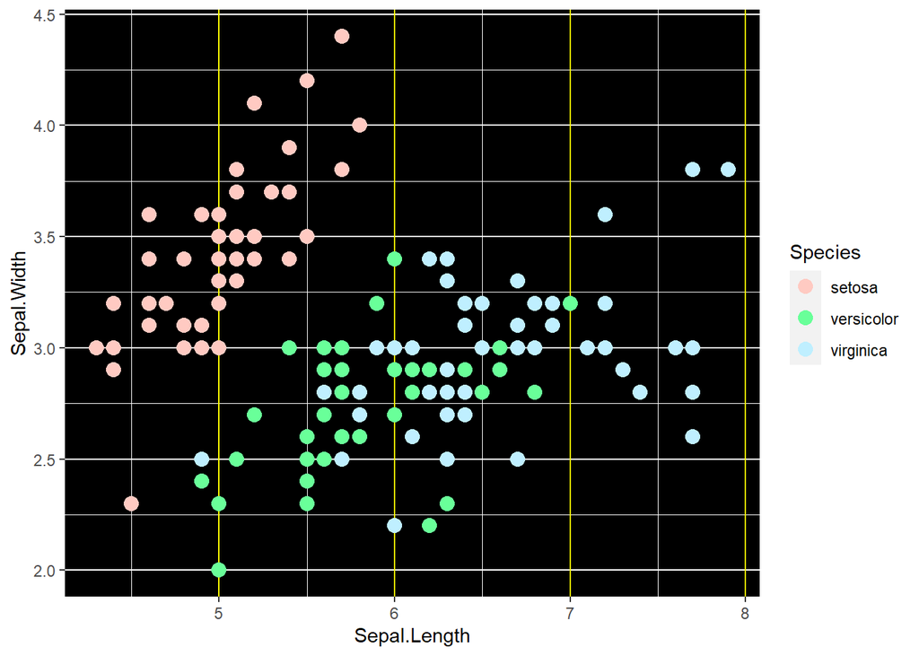

```r
iris %>%
  ggplot(mapping = aes(x = Sepal.Length, y = Sepal.Width)) +
  geom_point(size = 3.5,
             mapping = aes(color = Species)) +
  scale_color_discrete(l = 95) +
  theme(panel.background = element_rect(fill = 'black'),
        panel.grid.major.x = element_line(color = 'yellow'),
        panel.grid.minor.x = element_line(color = 'white'))
```

We don’t have to go into such fine detail, we can use “macro” themes to make it easier to change the backgrounds.

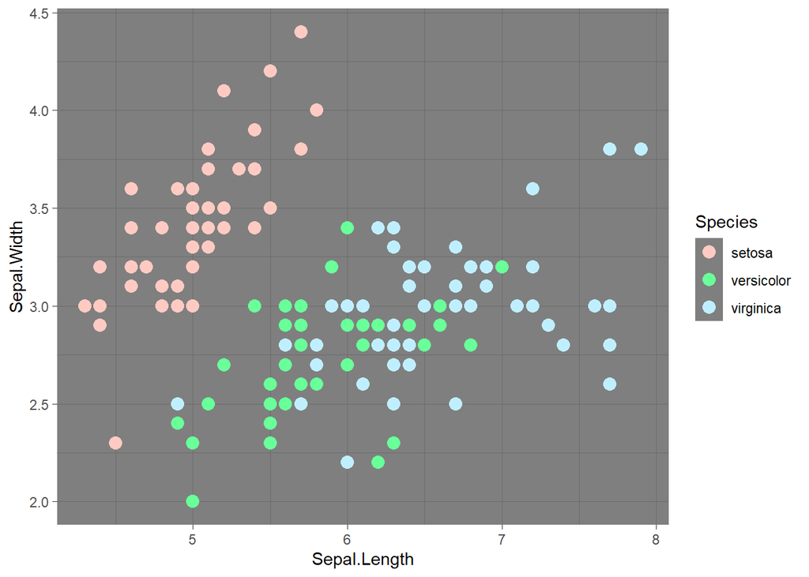

```r
iris %>%
  ggplot(mapping = aes(x = Sepal.Length, y = Sepal.Width)) +
  geom_point(size = 3.5,
             mapping = aes(color = Species)) +
  scale_color_discrete(l = 95) +
  theme_dark()
```

I personally like the black-white theme and I use darker colors.

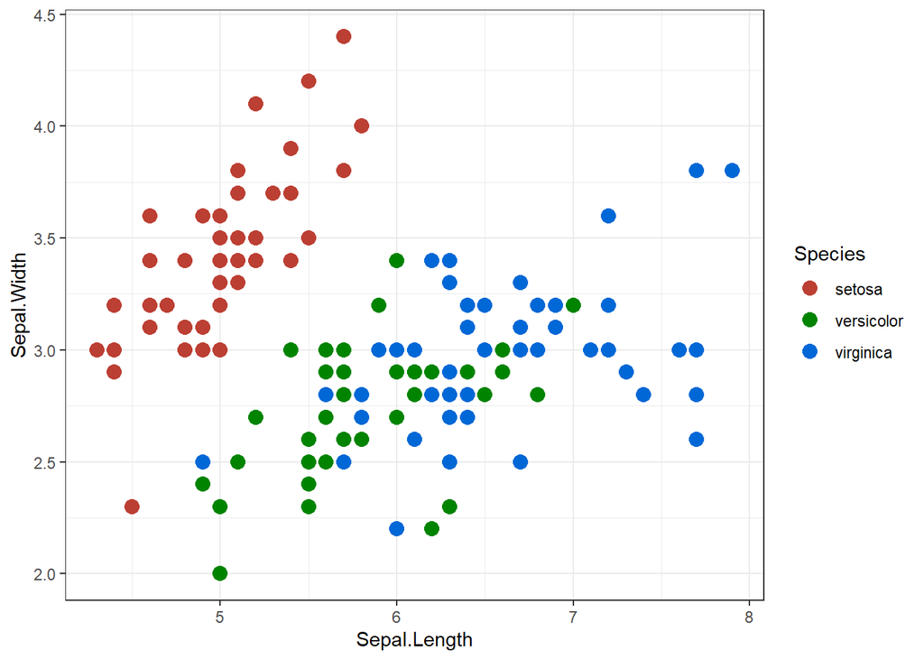

```r
iris %>%
  ggplot(mapping = aes(x = Sepal.Length, y = Sepal.Width)) +
  geom_point(size = 3.5,
             mapping = aes(color = Species)) +
  scale_color_discrete(l = 45) +
  theme_bw()
```

To move the legend we need another call to `theme()`.

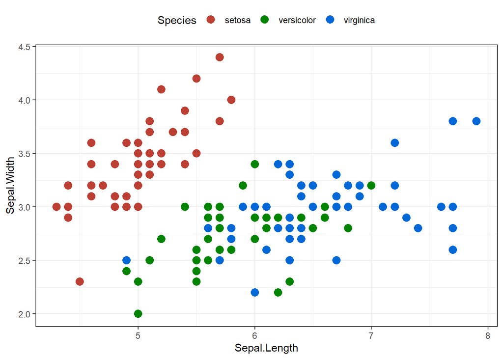

```r
iris %>%
  ggplot(mapping = aes(x = Sepal.Length, y = Sepal.Width)) +
  geom_point(size = 3.5,
             mapping = aes(color = Species)) +
  scale_color_discrete(l = 45) +
  theme_bw() +
  theme(legend.position = 'top')
```

Use the brewer color palettes.

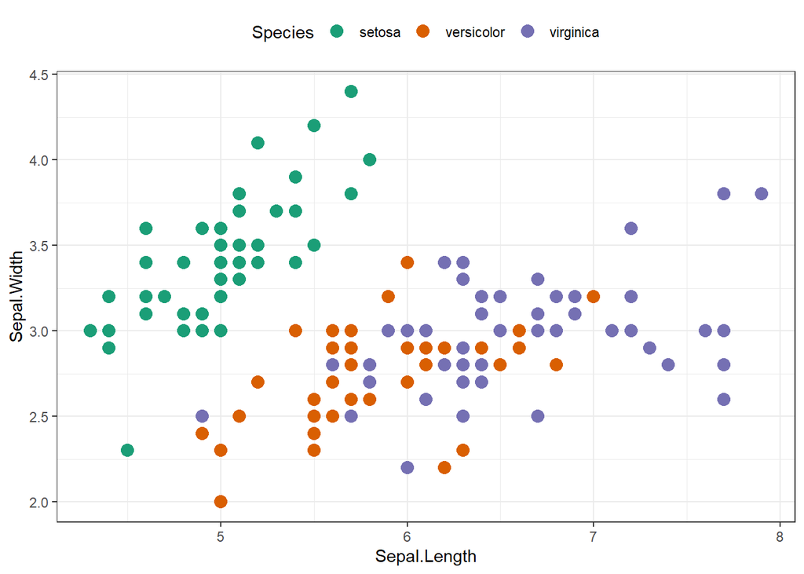

```r
iris %>%
  ggplot(mapping = aes(x = Sepal.Length, y = Sepal.Width)) +
  geom_point(size = 3.5,
             mapping = aes(color = Species)) +
  scale_color_brewer(palette = 'Dark2') +
  theme_bw() +
  theme(legend.position = 'top')
```

There are limited number of colors in the brewer qualitative palettes.

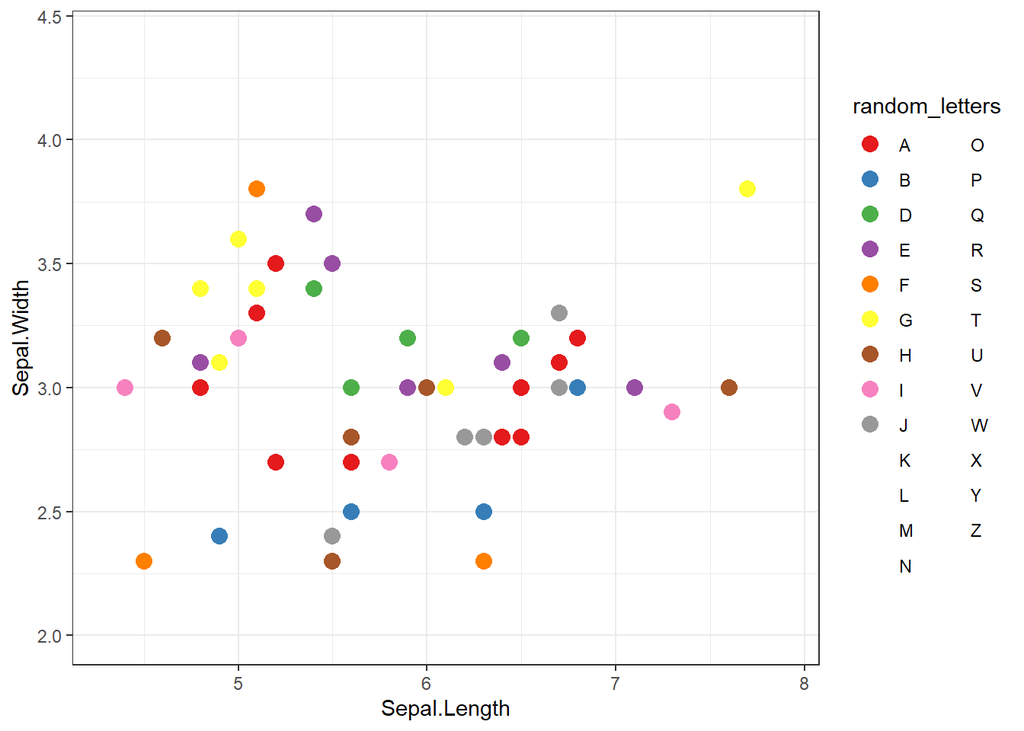

```r
set.seed(2130)
iris %>%
  mutate(random_letters = sample(LETTERS, size = n(), replace = TRUE)) %>%
  ggplot(mapping = aes(x = Sepal.Length, y = Sepal.Width)) +
  geom_point(mapping = aes(color = random_letters),
             size = 3.5) +
  scale_color_brewer(palette = 'Set1') +
  theme_bw()
```

Use color blind friendly palettes from `ggthemes`.

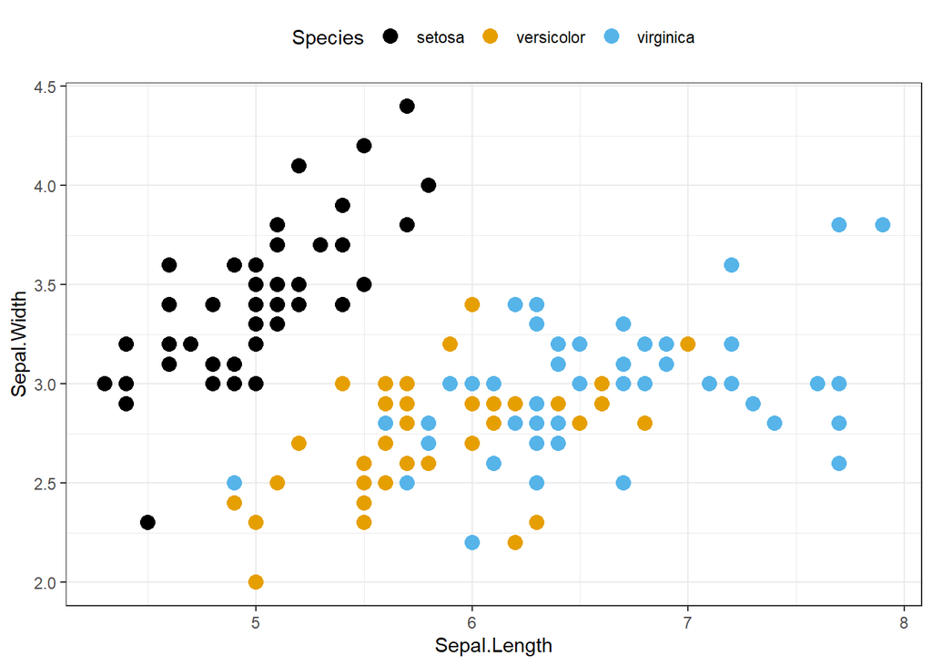

```r
iris %>%
  ggplot(mapping = aes(x = Sepal.Length, y = Sepal.Width)) +
  geom_point(mapping = aes(color = Species),
             size = 3.5) +
  ggthemes::scale_color_colorblind() +
  theme_bw() +
  theme(legend.position = 'top')
```

Another palette from `ggthemes`.

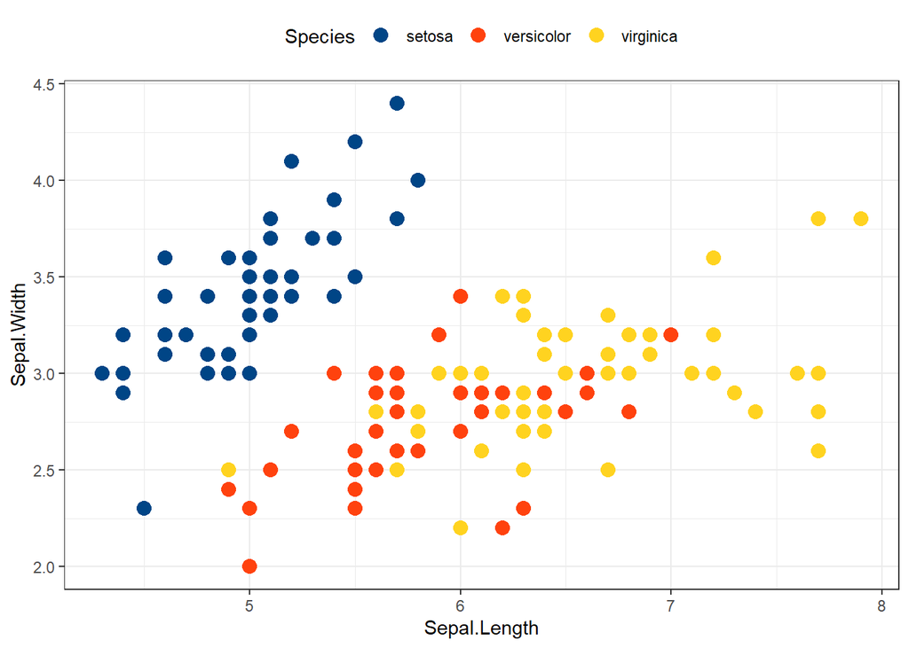

```r
iris %>%
  ggplot(mapping = aes(x = Sepal.Length, y = Sepal.Width)) +
  geom_point(mapping = aes(color = Species),
             size = 3.5) +
  ggthemes::scale_color_calc()+
  theme_bw() +
  theme(legend.position = 'top')
```

Both have very limited number of values.

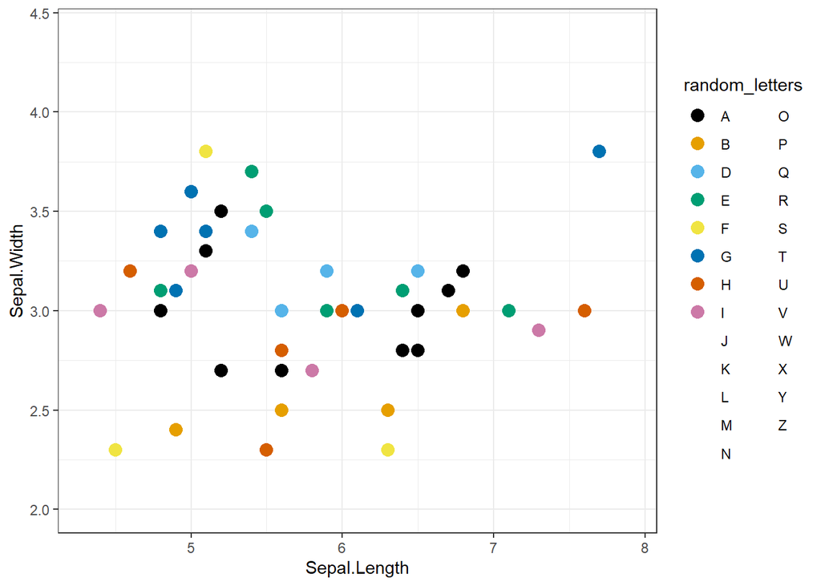

```r
set.seed(2130)
iris %>%
  mutate(random_letters = sample(LETTERS, size = n(), replace = TRUE)) %>%
  ggplot(mapping = aes(x = Sepal.Length, y = Sepal.Width)) +
  geom_point(mapping = aes(color = random_letters),
             size = 3.5) +
  ggthemes::scale_color_colorblind() +
  theme_bw()
```

Excel colors.

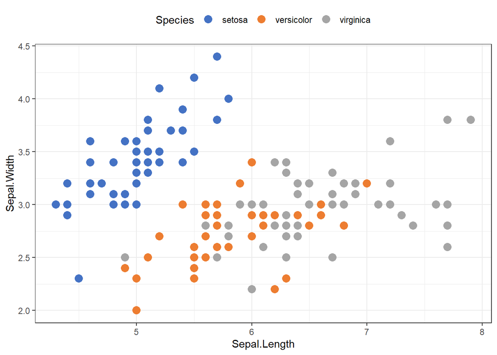

```r
iris %>%
  ggplot(mapping = aes(x = Sepal.Length, y = Sepal.Width)) +
  geom_point(mapping = aes(color = Species),
             size = 3.5) +
  ggthemes::scale_color_excel_new(theme = 'Office Theme') +
  theme_bw() +
  theme(legend.position = 'top')
```

Excel theme.

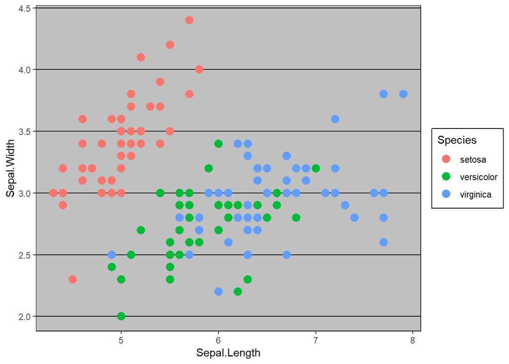

```r
iris %>%
  ggplot(mapping = aes(x = Sepal.Length, y = Sepal.Width)) +
  geom_point(mapping = aes(color = Species),
             size = 3.5) +
  ggthemes::theme_excel()
```

Economist has a theme.

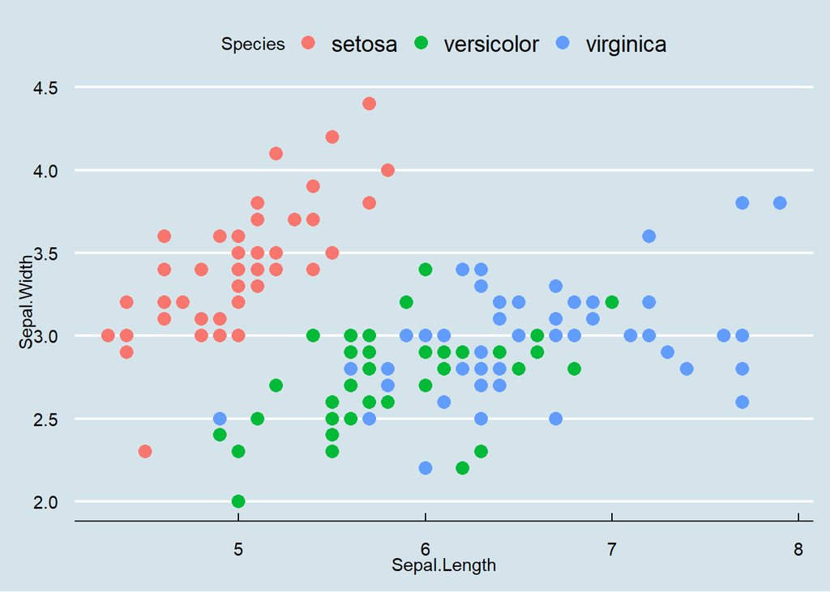

```r
iris %>%
  ggplot(mapping = aes(x = Sepal.Length, y = Sepal.Width)) +
  geom_point(mapping = aes(color = Species),
             size = 3.5) +
  ggthemes::theme_economist()
```

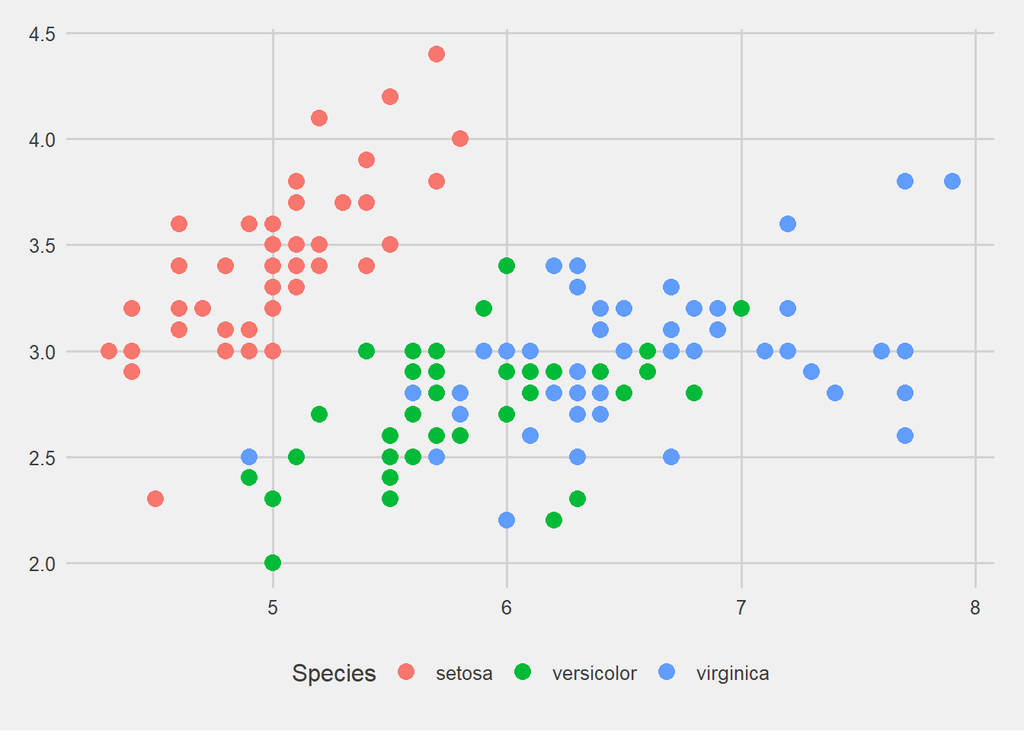

```r
iris %>%
  ggplot(mapping = aes(x = Sepal.Length, y = Sepal.Width)) +
  geom_point(mapping = aes(color = Species),
             size = 3.5) +
  ggthemes::theme_fivethirtyeight()
```